# DS152 Introduction to Data Science (2)

Assignment 1: Tidyverse Recap

Author

Prof. Niamh Cahill

## **Solutions** **[Total = 20 Marks]**

1. How many observations are in the dataset? **[2 Mark]**
- 902,297
2. Assume you want to create the summary below, which sums up the number of fatalities within each event type and then arranges by the total fatalities, in descending order. **[8 Marks]**

```r
nat_disaster_summary <- nat_disaster_dat %>%
                          group_by(EVTYPE) %>%
                          summarise(total_fatalities = sum(FATALITIES)) %>%
                          arrange(desc(total_fatalities))
nat_disaster_summary
```

```
# A tibble: 977 × 2
   EVTYPE         total_fatalities
   <chr>                     <dbl>
 1 TORNADO                    5633
 2 EXCESSIVE HEAT             1903
 3 FLASH FLOOD                 978
 4 HEAT                        937
 5 LIGHTNING                   816
 6 TSTM WIND                   504
 7 FLOOD                       470
 8 RIP CURRENT                 368
 9 HIGH WIND                   248
10 AVALANCHE                   224
# ℹ 967 more rows
```

In the code below, what should [A], [B], [C] and [D] be replaced with to create this summary?

```r
nat_disaster__summary <- nat_disaster_dat %>%
                          group_by([A]) %>%
                          [B](total_fatalities = [C])) %>%
                          arrange([D](total_fatalities))
```

[A] = EVTYPE

[B] = summarise

[C] = sum(FATALITIES)

[D] = desc

3. Now assume you want to filter the summarised data from (ii) so that you have a dataset with only events where the total fatalities are greater than 200, as shown.

```r
nat_disaster_filter <- nat_disaster_summary %>%
                        filter(total_fatalities > 200)
nat_disaster_filter
```

```
# A tibble: 12 × 2
   EVTYPE         total_fatalities
   <chr>                     <dbl>
 1 TORNADO                    5633
 2 EXCESSIVE HEAT             1903
 3 FLASH FLOOD                 978
 4 HEAT                        937
 5 LIGHTNING                   816
 6 TSTM WIND                   504
 7 FLOOD                       470
 8 RIP CURRENT                 368
 9 HIGH WIND                   248
10 AVALANCHE                   224
11 WINTER STORM                206
12 RIP CURRENTS                204
```

In the code below, what should [A] and [B] be replaced with to create the filtered dataet? **[4 Marks]**

```r
nat_disaster_filter <- nat_disaster_summary %>%
                        [A]([B])
```

4. Now assume you want to create the following barplot which shows the total fatalities per event type, using the filtered data from part (iii).

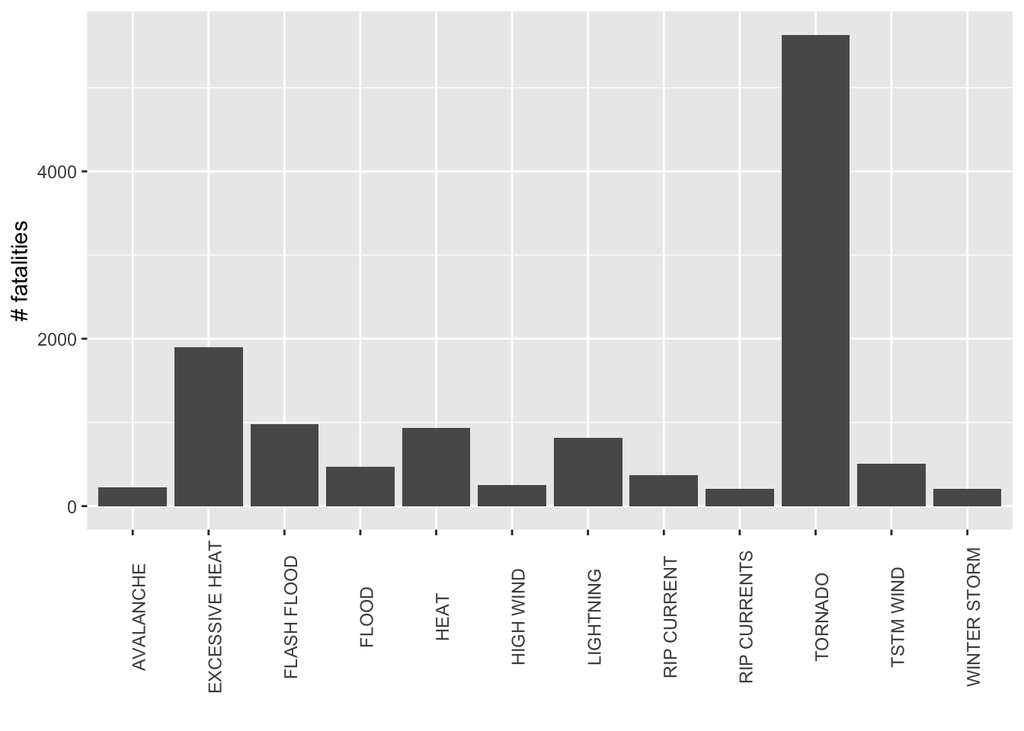

```r
ggplot(nat_disaster_filter, aes(x = EVTYPE, y = total_fatalities)) +
  geom_bar(stat="identity") +
  theme(axis.text.x = element_text(angle = 90)) +
  xlab("") +
  ylab("# fatalities")
```

In the code below, what should [A], [B] and [C] be replaced with to create the plot? **[6 Marks]**

```r
ggplot(nat_disaster_filter, aes(x = [A], y = [B])) +
  [C](stat="identity") +
  theme(axis.text.x = element_text(angle = 90)) +
  xlab("") +
  ylab("# fatalities")
```

[A] = EVTYPE

[B] = total_fatalities

[C] = geom_bar